# Clustering

Cho dữ liệu **data3.txt**  
Yêu cầu: Đọc dữ liệu, chuẩn hóa dữ liệu (nếu cần) và **chọn một thuật toán thích hợp** để thực hiện việc **phân cụm dữ liệu** dựa trên hai cột trong dữ liệu được cung cấp.

1. Vẽ biểu đồ thể hiện mối quan hệ giữa hai cột dữ liệu nói trên. Cho nhận xét dựa trên biểu đồ.
2. Áp dụng thuật toán thích hợp. Dựa trên cơ sở nào để cho rằng thuật toán này thích hợp?
3. Tìm kết quả => có bao nhiêu cụm => mẫu nào thuộc cụm nào?
4. Nhận xét trên cụm.
5. Với X_new như sau : X_new = [[5.5, 9.5], [16.5, 15.5], [30.0, 10.0], [29.375, 3.0]] thì mỗi mẫu sẽ lần lượt thuộc cụm nào?
6. Vẽ hình (với mỗi cụm là một màu), trên hình có biểu diễn luôn kết quả của X_new.

**---------------------------------------------------- DATA OVERVIEW ----------------------------------------------------------**

```python
import pandas as pd
data = pd.read_csv('du lieu cung cap/data3.txt', header=None)
```

```python
data.info()
```

```
<class 'pandas.core.frame.DataFrame'>
RangeIndex: 195 entries, 0 to 194
Data columns (total 2 columns):
0    195 non-null float64
1    195 non-null float64
dtypes: float64(2)
memory usage: 3.1 KB
```

```python
print('Number of rows:',data.shape[0])
print('Number of columns:',data.shape[1])
```

```
Number of rows: 195
Number of columns: 2
```

```python
data.head()
```

|  | 0 | 1 |
| --- | --- | --- |
| 0 | 1.225 | 2.7 |
| 1 | 4.125 | 5.1 |
| 2 | 6.375 | 8.6 |
| 3 | 10.475 | 11.3 |
| 4 | 13.475 | 13.2 |

```python
descrip = data.describe(include='all').transpose()
pd.options.display.max_rows = 1000
display(descrip)
pd.options.display.max_rows = 15
```

|  | count | mean | std | min | 25% | 50% | 75% | max |
| --- | --- | --- | --- | --- | --- | --- | --- | --- |
| 0 | 195.0 | 20.072692 | 10.234654 | 0.225 | 11.375 | 22.925 | 29.575 | 32.375 |
| 1 | 195.0 | 10.125128 | 5.643750 | 0.650 | 5.000 | 10.050 | 15.475 | 18.800 |

**1. Vẽ biểu đồ thể hiện mối quan hệ giữa hai cột dữ liệu nói trên. Cho nhận xét dựa trên biểu đồ.**

```python
import matplotlib.pyplot as plt
import seaborn as sns
```

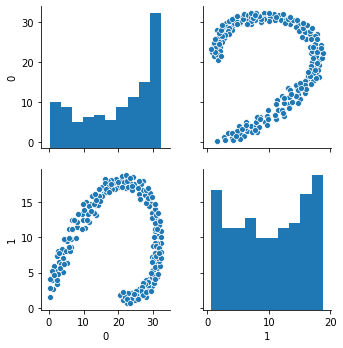

```python
sns.pairplot(data)
plt.show()
```

**2. Áp dụng thuật toán thích hợp. Dựa trên cơ sở nào để cho rằng thuật toán này thích hợp?**

Đây là bài toán Clustering thuộc nhóm Unsupervised Learning. Một số model có thể dùng cho dạng bài toán này:

```
1. K-Means
2. Hierirachical clustering
3. GMM
```

**---------------------------------------------------- 1. K-MEANS ----------------------------------------------------------**

```python
import numpy as np
from sklearn.cluster import KMeans
from scipy.spatial.distance import cdist
```

```python
# k means determine k
distortions = []
K = range(1,15)
for k in K:
    kmeanModel = KMeans(n_clusters=k).fit(data)
    kmeanModel.fit(data)
    distortions.append(sum(np.min(cdist(data, kmeanModel.cluster_centers_,
                                        'euclidean'), axis=1)) / data.shape[0])
```

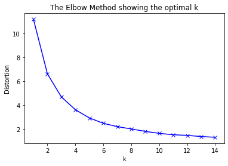

```python
# Plot the elbow
plt.plot(K, distortions, 'bx-')
plt.xlabel('k')
plt.ylabel('Distortion')
plt.title('The Elbow Method showing the optimal k')
plt.show()
```

```python
k = 6
kmeans = KMeans(n_clusters=k)
kmeans.fit(data)
```

```
KMeans(algorithm='auto', copy_x=True, init='k-means++', max_iter=300,
       n_clusters=6, n_init=10, n_jobs=None, precompute_distances='auto',
       random_state=None, tol=0.0001, verbose=0)
```

```python
centroids = kmeans.cluster_centers_
labels = kmeans.labels_
print(centroids)
print(labels)
```

```
[[30.90833333  7.19230769]
 [11.06370968 13.57419355]
 [19.7203125  17.478125  ]
 [28.81293103 15.01206897]
 [25.43790323  2.07419355]
 [ 3.35075758  6.48939394]]
[5 5 5 1 1 2 2 3 3 0 0 0 4 4 5 1 1 1 2 2 2 3 3 3 3 0 0 0 0 4 4 4 4 4 4 4 0
 0 0 0 0 0 0 0 0 3 3 3 3 3 3 3 3 3 3 3 3 3 3 3 3 3 2 2 2 2 2 2 2 2 2 2 2 2
 2 2 2 2 2 2 2 1 1 1 1 1 1 1 1 1 5 5 5 5 5 5 5 5 5 5 5 5 5 5 5 5 5 5 1 1 1
 1 1 1 1 1 1 1 1 1 1 5 5 5 5 5 5 5 5 5 5 5 1 1 1 1 2 2 2 2 2 2 2 2 3 3 0 0
 0 0 0 0 0 0 0 4 4 4 4 4 4 4 4 4 4 4 4 4 4 4 4 4 4 4 4 4 4 0 0 0 0 0 0 0 0
 0 0 0 0 0 0 3 3 3 3]
```

```python
data['Group'] = pd.Series(labels)
data.head()
```

|  | 0 | 1 | Group |
| --- | --- | --- | --- |
| 0 | 1.225 | 2.7 | 5 |
| 1 | 4.125 | 5.1 | 5 |
| 2 | 6.375 | 8.6 | 5 |
| 3 | 10.475 | 11.3 | 1 |
| 4 | 13.475 | 13.2 | 1 |

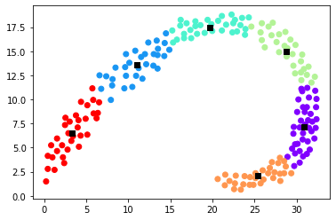

```python
plt.scatter(data[0], data[1], c= data.Group, cmap='rainbow')
plt.scatter(centroids[:, 0],centroids[:, 1], marker = "s",c='black')
plt.show()
```

**---------------------------------------------------- 2. HIERARCHICAL CLUSTERING ----------------------------------------------------------**

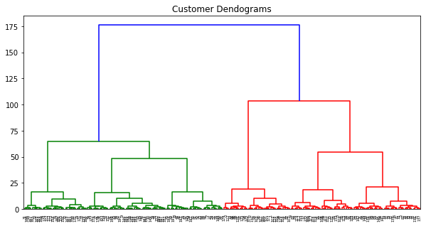

```python
import scipy.cluster.hierarchy as shc
plt.figure(figsize=(10, 5))
plt.title("Customer Dendograms")
dend = shc.dendrogram(shc.linkage(data, method='ward'))
```

```python
cluster = 6
from sklearn.cluster import AgglomerativeClustering
cluster = AgglomerativeClustering(n_clusters=cluster,
                                  affinity='euclidean', linkage='ward')
cluster.fit(data)
```

```
AgglomerativeClustering(affinity='euclidean', compute_full_tree='auto',
                        connectivity=None, distance_threshold=None,
                        linkage='ward', memory=None, n_clusters=6)
```

```python
cluster.labels_
```

```
array([2, 2, 2, 1, 1, 0, 0, 4, 4, 5, 5, 5, 3, 3, 2, 1, 1, 1, 0, 0, 0, 0,
       4, 4, 4, 5, 5, 5, 5, 3, 3, 3, 3, 3, 3, 3, 5, 5, 5, 5, 5, 5, 5, 5,
       5, 4, 4, 4, 4, 4, 4, 4, 4, 4, 4, 4, 4, 4, 4, 4, 4, 4, 0, 0, 0, 0,
       0, 0, 0, 0, 0, 0, 0, 0, 0, 0, 0, 0, 0, 0, 0, 1, 1, 1, 1, 1, 1, 1,
       1, 1, 2, 2, 2, 2, 2, 2, 2, 2, 2, 2, 2, 2, 2, 2, 2, 2, 2, 2, 1, 1,
       1, 1, 1, 1, 1, 1, 1, 1, 1, 1, 1, 2, 2, 2, 2, 2, 2, 2, 2, 2, 2, 2,
       1, 1, 1, 1, 0, 0, 0, 0, 0, 0, 0, 0, 4, 4, 5, 5, 5, 5, 5, 5, 5, 5,
       5, 3, 3, 3, 3, 3, 3, 3, 3, 3, 3, 3, 3, 3, 3, 3, 3, 3, 3, 3, 3, 3,
       3, 5, 5, 5, 5, 5, 5, 5, 5, 5, 5, 5, 5, 5, 5, 4, 4, 4, 4],
      dtype=int64)
```

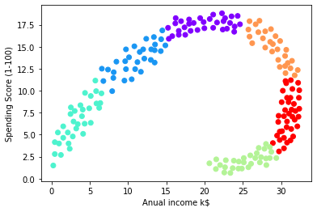

```python
plt.scatter(data[0], data[1], c=cluster.labels_, cmap='rainbow')
plt.xlabel("Anual income k$")
plt.ylabel("Spending Score (1-100)")
plt.show()
```

**---------------------------------------------------- 3. GMM ----------------------------------------------------------**

```python
from sklearn.mixture import GaussianMixture
```

```python
from sklearn import metrics
list_sil = []
K = range(2,8)
for k in K:
    gmm = GaussianMixture(n_components=k)
    gmm.fit(data)
    labels = gmm.predict(data)
    sil = metrics.silhouette_score(data, labels, metric='euclidean')
    list_sil.append(sil)
```

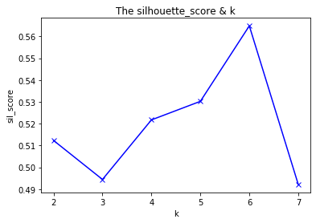

```python
# Plot
plt.plot(K, list_sil, 'bx-')
plt.xlabel('k')
plt.ylabel('sil_score')
plt.title('The silhouette_score & k')
plt.show()
```

```python
# Chọn k = 6 vì có silhouette_score cao nhất
```

```python
gmm = GaussianMixture(n_components=6)
gmm.fit(data)
```

```
GaussianMixture(covariance_type='full', init_params='kmeans', max_iter=100,
                means_init=None, n_components=6, n_init=1, precisions_init=None,
                random_state=None, reg_covar=1e-06, tol=0.001, verbose=0,
                verbose_interval=10, warm_start=False, weights_init=None)
```

```python
print(gmm.weights_)
```

```
[0.15897436 0.14871795 0.15897436 0.16923077 0.16410256 0.2       ]
```

```python
print(gmm.means_)
```

```
[[11.06370968 13.57419355  1.        ]
 [28.81293103 15.01206897  3.        ]
 [25.43790323  2.07419355  4.        ]
 [ 3.35075758  6.48939394  5.        ]
 [19.7203125  17.478125    2.        ]
 [30.90833333  7.19230769  0.        ]]
```

```python
print(gmm.covariances_)
```

```
[[[ 5.72656708e+00  2.97745057e+00  1.17692958e-31]
  [ 2.97745057e+00  2.77659309e+00  3.94430453e-31]
  [ 1.17692958e-31  3.94430453e-31  1.00000000e-06]]

 [[ 4.05166568e+00 -3.18269917e+00  4.62435703e-30]
  [-3.18269917e+00  3.47994155e+00  1.87694491e-30]
  [ 4.62435703e-30  1.87694491e-30  1.00000000e-06]]

 [[ 6.01031838e+00  1.28573621e+00  1.67951031e-30]
  [ 1.28573621e+00  6.95625350e-01  2.00396117e-31]
  [ 1.67951031e-30  2.00396117e-31  1.00000000e-06]]

 [[ 3.45562543e+00  3.57428834e+00  0.00000000e+00]
  [ 3.57428834e+00  5.44254003e+00  0.00000000e+00]
  [ 0.00000000e+00  0.00000000e+00  1.00000000e-06]]

 [[ 8.12630715e+00  9.04663086e-01  0.00000000e+00]
  [ 9.04663086e-01  5.58428734e-01  0.00000000e+00]
  [ 0.00000000e+00  0.00000000e+00  1.00000000e-06]]

 [[ 8.05812966e-01  8.59551282e-01  0.00000000e+00]
  [ 8.59551282e-01  5.14712132e+00  0.00000000e+00]
  [ 0.00000000e+00  0.00000000e+00  1.00000000e-06]]]
```

```python
types = gmm.predict(data)
```

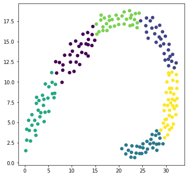

```python
# plot mixture of Gaussians
plt.figure(figsize=(6,6))
# X, Y = np.meshgrid(np.linspace(0,1), np.linspace(0,1))
# XX = np.array([X.ravel(), Y.ravel()]).T
# Z = gmm.score_samples(XX)
# Z = Z.reshape((50,50))

# plt.contour(X, Y, Z)
plt.scatter(data[0], data[1], c=types)
# plt.scatter(gmm.means_[:,0], gmm.means_[:,1], color="red")
plt.show()
```

**3. Tìm kết quả => có bao nhiêu cụm => mẫu nào thuộc cụm nào?**  
**4. Nhận xét trên cụm.**

Sau khi clustering thì chia được 6 cụm theo thống kê inputs như bên dưới

```python
data.groupby('Group').agg(['min', 'max'])
```

| Group | 0 min | 0 max | 1 min | 1 max |
| --- | --- | --- | --- | --- |
| 0 | 28.925 | 32.375 | 3.10 | 11.20 |
| 1 | 6.575 | 14.875 | 9.95 | 16.85 |
| 2 | 15.225 | 24.325 | 15.90 | 18.80 |
| 3 | 24.625 | 32.175 | 11.75 | 17.95 |
| 4 | 20.625 | 29.375 | 0.65 | 3.95 |
| 5 | 0.225 | 6.525 | 1.50 | 11.15 |

**5. Với X_new như sau : X_new = [[5.5, 9.5], [16.5, 15.5], [30.0, 10.0], [29.375, 3.0]] thì mỗi mẫu sẽ lần lượt thuộc cụm nào?**  
**6. Vẽ hình (với mỗi cụm là một màu), trên hình có biểu diễn luôn kết quả của X_new.**

```python
X_new = np.array([[5.5, 9.5], [16.5, 15.5], [30.0, 10.0], [29.375, 3.0]])
```

```python
X_new
```

```
array([[ 5.5  ,  9.5  ],
       [16.5  , 15.5  ],
       [30.   , 10.   ],
       [29.375,  3.   ]])
```

```python
pred = kmeans.predict(X_new)
pred
```

```
array([5, 2, 0, 4])
```

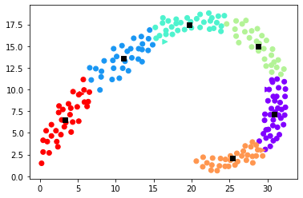

```python
plt.scatter(data[0], data[1], c= data.Group, cmap='rainbow')
plt.scatter(centroids[:, 0],centroids[:, 1], marker = "s",c='black')
plt.scatter(X_new[:,0],X_new[:,1],
            marker=">", c=pred, cmap='rainbow')
plt.show()
```